# Summarising EDA Features

In this notebook we summarise and visualise the EDA features we extracted.

```r
eda_df <- events %>%
  select(ID, EmotionalEatingEpisodes, Event, Stress) %>%
  mutate(ID = as.character(ID)) %>%
  left_join(eda_df, by = c("ID", "Event"))
```

[output not shown]

# Accelerometer Features

## Step Count

`Step count` summaries for both episodes and controls:

```r
eda_df %>%
  group_by(ID) %>%
  select(ID,
         Event,
         EmotionalEatingEpisodes,
         `Step count`,
         Stress) %>%
  distinct() %>%
  mutate(Y = ifelse(EmotionalEatingEpisodes == 1, "Episode", "Control")) %>%
  filter(!(Stress > 4))%>% #filter high stress
  #select(ID, `Step count`, `Mean step time during movement`, `Percent stillness`) %>%
  do(tidy(summary(.$`Step count`))) %>%
  kable()
```

```
|ID  | minimum|     q1| median|      mean|     q3| maximum|  na|
|:---|-------:|------:|------:|---------:|------:|-------:|---:|
|200 |       2|  23.00|   94.5| 243.01562| 335.00|    1939|  52|
|201 |       2|  50.00|  175.0| 382.50833| 493.50|    2495|  34|
|202 |       2|  42.50|  147.0| 257.71552| 279.50|    2540|  78|
|205 |       0|  43.00|  177.0| 235.16071| 337.50|     966|  51|
|207 |       2|  26.00|   98.0| 175.01980| 272.00|    1191| 132|
|208 |       0|   2.00|    7.0|  71.69388| 100.00|     582|  84|
|212 |       1|  54.00|  119.0| 266.22472| 258.00|    2469|  68|
|213 |      17|  97.00|  210.0| 285.26415| 371.00|    1700|  73|
|214 |       2|  16.50|   73.0| 152.81633| 145.00|    1885|  75|
|215 |       2|  20.50|   70.0| 109.22989| 158.50|     571|  67|
|217 |       2|  69.00|  131.0| 223.18898| 284.50|     993|  57|
|218 |       2|  79.00|  174.5| 221.64773| 286.00|    1282|  29|
|219 |       2|  17.00|   64.0| 176.39175| 162.00|    2112|  58|
|220 |       2|  33.50|  110.0| 175.30120| 246.50|    1202|  76|
|222 |       0|  30.25|  116.5| 265.14815| 523.50|    1245|  53|
|223 |       2|  32.75|   74.0| 141.53846| 179.00|    1903|  36|
|224 |       4| 101.50|  203.0| 286.17045| 358.50|    1718|  37|
|225 |       2|  35.50|  112.0| 203.88148| 274.00|    1566|  68|
|226 |       2|  29.75|   86.5| 129.75962| 179.00|     543|  48|
|227 |       2|  10.00|   28.5| 158.35294| 133.25|     904| 107|
|228 |       2|  35.00|  164.0| 238.09091| 307.00|    2631|  65|
```

`Step count` summaries for episodes:

```r
eda_df %>%
  group_by(ID) %>%
  select(ID,
         Event,
         EmotionalEatingEpisodes,
         `Step count`,
         Stress) %>%
  distinct() %>%
  mutate(Y = ifelse(EmotionalEatingEpisodes == 1, "Episode", "Control")) %>%
  filter(!(Stress > 4 & Y == "Episode"))%>% #filter high stress
  do(tidy(summary(.$`Step count`))) %>%
  kable(caption = "\"Step Count\" Summary During Episodes")
```

```
|ID  | minimum|     q1| median|      mean|     q3| maximum|  na|
|:---|-------:|------:|------:|---------:|------:|-------:|---:|
|200 |       2|  23.00|   94.5| 243.01562| 335.00|    1939|  52|
|201 |       2|  50.25|  172.5| 377.74590| 493.00|    2495|  34|
|202 |       2|  43.50|  147.0| 258.74576| 280.50|    2540|  78|
|205 |       0|  53.75|  172.5| 234.53425| 325.00|     966|  55|
|207 |       2|  26.00|   98.0| 175.01980| 272.00|    1191| 132|
|208 |       0|   2.00|    7.0|  71.69388| 100.00|     582|  86|
|212 |       1|  54.00|  119.0| 266.22472| 258.00|    2469|  68|
|213 |      17|  97.00|  210.0| 285.26415| 371.00|    1700|  73|
|214 |       2|  16.50|   73.0| 152.81633| 145.00|    1885|  76|
|215 |       2|  20.50|   70.0| 109.22989| 158.50|     571|  67|
|217 |       2|  68.00|  131.0| 220.30233| 284.00|     993|  58|
|218 |       2|  79.00|  174.5| 221.64773| 286.00|    1282|  29|
|219 |       2|  19.75|   76.0| 197.67742| 184.00|    2112|  61|
|220 |       2|  34.50|  110.0| 175.59770| 251.00|    1202|  85|
|222 |       0|  30.25|  116.5| 265.14815| 523.50|    1245|  53|
|223 |       0|  31.25|   65.0| 130.85294| 158.00|    1903|  40|
|224 |       4| 102.00|  204.0| 286.96907| 371.25|    1718|  40|
|225 |       0|  35.75|  111.0| 202.33571| 273.50|    1566|  69|
|226 |       2|  29.75|   86.5| 129.75962| 179.00|     543|  48|
|227 |       2|  10.00|   28.5| 158.35294| 133.25|     904| 107|
|228 |       2|  35.00|  161.0| 234.87059| 305.50|    2631|  70|
```

`Step count` summaries for controls:

```r
eda_df %>%
  group_by(ID) %>%
  select(ID,
         Event,
         EmotionalEatingEpisodes,
         `Step count`,
         Stress) %>%
  distinct() %>%
  mutate(Y = ifelse(EmotionalEatingEpisodes == 1, "Episode", "Control")) %>%
  filter(!(Stress > 4 & Y == "Control") & Y != "Episode")%>% #filter high stress
  do(tidy(summary(.$`Step count`))) %>%
  kable(caption = "\"Step Count\" Summary During Controls")
```

[output not shown]

Visualised:

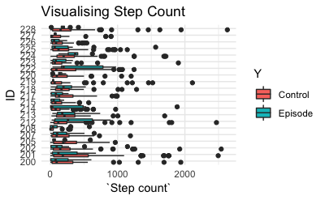

```r
eda_df %>%
  group_by(ID) %>%
  select(ID,
         Event,
         EmotionalEatingEpisodes,
         `Step count`,
         Stress) %>%
  distinct() %>%
  mutate(Y = ifelse(EmotionalEatingEpisodes == 1, "Episode", "Control")) %>%
  filter(!(Stress > 4)) %>%
  ggplot(aes(x=ID,y=`Step count`)) +
  geom_boxplot(aes(fill = Y)) +
  labs(title = "Visualising Step Count") +
  theme_minimal() +
  coord_flip()
```

## Mean step time during observations

`Mean step time during observation` summaries for both episodes and controls:

```r
eda_df %>%
  group_by(ID) %>%
  select(ID,
         Event,
         EmotionalEatingEpisodes,
         `Mean step time during movement`,
         Stress) %>%
  distinct() %>%
  mutate(Y = ifelse(EmotionalEatingEpisodes == 1, "Episode", "Control")) %>%
  filter(!(Stress > 4))%>% #filter high stress
  do(tidy(summary(.$`Mean step time during movement`))) %>%
  kable(caption = "\"Mean step time during movement\" Summary During Episodes and Controls")
```

```
|ID  |   minimum|       q1|    median|     mean|       q3|   maximum|  na|
|:---|---------:|--------:|---------:|--------:|--------:|---------:|---:|
|200 |  9.153995| 46.59324| 133.87089| 519.0125| 446.3750| 7074.5000|  55|
|201 |  6.784846| 30.56540|  79.76157| 272.3545| 286.4714| 5241.5000|  37|
|202 |  3.000000| 57.31183| 103.70270| 243.5140| 246.9228| 2205.8000|  82|
|205 | 17.701832| 44.79974|  85.38557| 179.7993| 262.7650|  978.4091|  58|
|207 |  3.000000| 64.62835| 139.53728| 430.0149| 397.9211| 4946.0000| 132|
|208 |  7.000000| 58.79610| 132.46615| 246.9086| 319.6752| 1823.8000| 106|
|212 |  0.000000| 57.87479| 131.69104| 207.0804| 232.9782| 1509.4286|  69|
|213 |  9.597096| 42.89683|  77.05977| 123.4508| 145.1008|  867.5667|  73|
|214 |  3.000000| 67.86176| 160.94608| 452.5078| 385.9375| 7056.5000|  84|
|215 | 33.136452| 89.52300| 198.77020| 578.7924| 561.8233| 4732.0000|  71|
|217 |  3.000000| 46.29096| 105.11232| 217.7549| 179.0995| 4141.7500|  58|
|218 | 13.857778| 56.98820|  87.96950| 215.6962| 182.1957| 3369.0000|  31|
|219 |  8.592611| 90.22381| 210.45635| 485.7725| 669.2000| 2962.8750|  62|
|220 |  3.000000| 56.40632| 106.03698| 266.1441| 220.2077| 2646.7500|  83|
|222 |  3.000000| 30.40191|  81.75758| 319.0329| 282.4639| 7050.5000|  66|
|223 |  3.000000| 67.15552| 164.78074| 468.0757| 351.1017| 6822.0000|  42|
|224 |  3.000000| 45.55367|  80.48032| 182.6108| 148.5696| 2034.9286|  38|
|225 | 12.761510| 54.82705| 101.50615| 252.1743| 326.0010| 2821.2000|  79|
|226 |  3.000000| 66.57169| 135.38855| 311.8304| 343.5475| 3255.1667|  50|
|227 | 19.401744| 98.57909| 500.69565| 647.5555| 824.4583| 2184.2500| 110|
|228 |  6.240626| 52.01124|  91.78459| 346.7192| 332.0455| 3938.0000|  69|
```

`Mean step time during observation` summaries for episodes:

```r
eda_df %>%
  group_by(ID) %>%
  select(ID,
         Event,
         EmotionalEatingEpisodes,
         `Mean step time during movement`,
         Stress) %>%
  distinct() %>%
  mutate(Y = ifelse(EmotionalEatingEpisodes == 1, "Episode", "Control")) %>%
  filter(!(Stress > 4 & Y == "Episode"))%>% #filter high stress
  do(tidy(summary(.$`Mean step time during movement`))) %>%
  kable(caption = "\"Mean step time during movement\" Summary During Episodes")
```

```
|ID  |   minimum|       q1|    median|     mean|       q3|   maximum|  na|
|:---|---------:|--------:|---------:|--------:|--------:|---------:|---:|
|200 |  9.153995| 46.59324| 133.87089| 519.0125| 446.3750| 7074.5000|  55|
|201 |  6.784846| 31.53782|  81.20281| 271.1049| 261.5519| 5241.5000|  37|
|202 |  3.000000| 55.47307| 102.91187| 240.1524| 243.7838| 2205.8000|  82|
|205 |  9.584165| 45.52050|  86.73718| 178.9520| 251.8911| 1167.7273|  62|
|207 |  3.000000| 64.62835| 139.53728| 430.0149| 397.9211| 4946.0000| 132|
|208 |  7.000000| 58.79610| 132.46615| 246.9086| 319.6752| 1823.8000| 108|
|212 |  0.000000| 57.87479| 131.69104| 207.0804| 232.9782| 1509.4286|  69|
|213 |  9.597096| 42.89683|  77.05977| 123.4508| 145.1008|  867.5667|  73|
|214 |  3.000000| 67.86176| 160.94608| 452.5078| 385.9375| 7056.5000|  85|
|215 | 33.136452| 89.52300| 198.77020| 578.7924| 561.8233| 4732.0000|  71|
|217 |  3.000000| 46.64719| 108.23409| 222.7950| 181.8897| 4141.7500|  59|
|218 | 13.857778| 56.98820|  87.96950| 215.6962| 182.1957| 3369.0000|  31|
|219 |  5.329457| 81.53607| 178.46125| 476.8031| 574.3194| 2962.8750|  65|
|220 |  3.000000| 56.40632| 106.03698| 263.2064| 235.2970| 2646.7500|  92|
|222 |  3.000000| 30.40191|  81.75758| 319.0329| 282.4639| 7050.5000|  66|
|223 |  3.000000| 65.63324| 164.78074| 427.1447| 376.8388| 6822.0000|  48|
|224 |  3.000000| 44.95567|  80.06111| 181.9951| 147.3750| 2034.9286|  41|
|225 | 12.761510| 54.82705| 101.50615| 248.6159| 325.3818| 2821.2000|  81|
|226 |  3.000000| 66.57169| 135.38855| 311.8304| 343.5475| 3255.1667|  50|
|227 | 19.401744| 98.57909| 500.69565| 647.5555| 824.4583| 2184.2500| 110|
|228 |  6.240626| 52.74195|  95.79245| 347.1887| 378.3239| 3938.0000|  74|
```

`Mean step time during observation` summaries for controls:

```r
eda_df %>%
  group_by(ID) %>%
  select(ID,
         Event,
         EmotionalEatingEpisodes,
         `Mean step time during movement`,
         Stress) %>%
  distinct() %>%
  mutate(Y = ifelse(EmotionalEatingEpisodes == 1, "Episode", "Control")) %>%
  filter(!(Stress > 4 & Y == "Control"))%>% #filter high stress
  do(tidy(summary(.$`Mean step time during movement`))) %>%
  kable(caption = "\"Step Count\" Summary During Controls")
```

```
|ID  |   minimum|        q1|    median|     mean|       q3|   maximum|  na|
|:---|---------:|---------:|---------:|--------:|--------:|---------:|---:|
|200 |  9.153995|  46.59324| 133.87089| 519.0125| 446.3750| 7074.5000|  55|
|201 |  6.784846|  30.56540|  79.76157| 272.3545| 286.4714| 5241.5000|  37|
|202 |  3.000000|  57.31183| 103.70270| 243.5140| 246.9228| 2205.8000|  82|
|205 | 17.701832|  41.54357|  85.75368| 174.2858| 208.2051|  978.4091|  58|
|207 |  3.000000|  63.38222| 134.16338| 426.3239| 392.8991| 4946.0000| 133|
|208 |  7.000000|  58.79610| 132.46615| 246.9086| 319.6752| 1823.8000| 106|
|212 |  0.000000|  57.87479| 131.69104| 207.0804| 232.9782| 1509.4286|  69|
|213 |  9.597096|  42.89683|  77.05977| 123.4508| 145.1008|  867.5667|  73|
|214 |  3.000000|  67.86176| 160.94608| 452.5078| 385.9375| 7056.5000|  85|
|215 | 33.136452|  89.52300| 198.77020| 578.7924| 561.8233| 4732.0000|  71|
|217 |  3.000000|  46.89414| 102.95804| 213.3039| 177.3132| 4141.7500|  58|
|218 | 13.857778|  56.98820|  87.96950| 215.6962| 182.1957| 3369.0000|  31|
|219 |  8.592611|  90.70357| 217.43790| 486.9182| 668.5333| 2962.8750|  62|
|220 |  3.000000|  56.40632| 106.03698| 266.1441| 220.2077| 2646.7500|  83|
|222 |  3.000000|  30.40191|  81.75758| 319.0329| 282.4639| 7050.5000|  66|
|223 |  3.000000|  68.09614| 187.44969| 467.2019| 352.2708| 6822.0000|  43|
|224 |  3.000000|  45.55367|  80.48032| 182.6108| 148.5696| 2034.9286|  38|
|225 | 12.761510|  55.09659| 101.50615| 252.4644| 328.2135| 2821.2000|  79|
|226 |  3.000000|  66.57169| 135.38855| 311.8304| 343.5475| 3255.1667|  50|
|227 | 19.401744| 110.69994| 500.34783| 631.8411| 805.8542| 2184.2500| 110|
|228 |  6.240626|  52.01124|  91.78459| 346.7192| 332.0455| 3938.0000|  69|
```

Visualised:

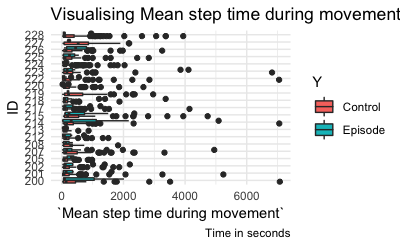

```r
eda_df %>%
  group_by(ID) %>%
  select(ID,
         Event,
         EmotionalEatingEpisodes,
         `Mean step time during movement`,
         Stress) %>%
  distinct() %>%
  mutate(Y = ifelse(EmotionalEatingEpisodes == 1, "Episode", "Control")) %>%
  filter(!(Stress > 4)) %>%
  ggplot(aes(x=ID,y=`Mean step time during movement`)) +
  geom_boxplot(aes(fill = Y)) +
  labs(title = "Visualising Mean step time during movement",
       caption = "Time in seconds") +
  theme_minimal() +
  coord_flip()
```

## Percent Stillness during observations

`Percent Stillness` summaries for both episodes and controls:

```r
eda_df %>%
  group_by(ID) %>%
  select(ID,
         Event,
         EmotionalEatingEpisodes,
         `Percent stillness`,
         Stress) %>%
  distinct() %>%
  mutate(Y = ifelse(EmotionalEatingEpisodes == 1, "Episode", "Control")) %>%
  filter(!(Stress > 4))%>% #filter high stress
  do(tidy(summary(.$`Percent stillness`))) %>%
  kable(caption = "\"Percent stillness during observation\" Summary During Episodes and Controls")
```

```
|ID  |   minimum|        q1|    median|      mean|        q3|   maximum|  na|
|:---|---------:|---------:|---------:|---------:|---------:|---------:|---:|
|200 | 0.0000000| 0.0055556| 0.0093751| 0.0100913| 0.0140627| 0.0208336|  52|
|201 | 0.0000000| 0.0032986| 0.0097223| 0.0092189| 0.0145835| 0.0208336|  34|
|202 | 0.0000000| 0.0027778| 0.0069445| 0.0083035| 0.0138890| 0.0208336|  78|
|205 | 0.0000000| 0.0006945| 0.0041667| 0.0059090| 0.0097223| 0.0194447|  51|
|207 | 0.0000000| 0.0048612| 0.0097223| 0.0094336| 0.0138890| 0.0208336| 132|
|208 | 0.0000000| 0.0083334| 0.0166669| 0.0135631| 0.0208336| 0.0208336|  84|
|212 | 0.0000000| 0.0027778| 0.0062501| 0.0071786| 0.0104168| 0.0208336|  68|
|213 | 0.0000000| 0.0020834| 0.0069445| 0.0078879| 0.0131946| 0.0194447|  73|
|214 | 0.0000000| 0.0045139| 0.0107640| 0.0106435| 0.0166669| 0.0208336|  75|
|215 | 0.0000000| 0.0045139| 0.0125001| 0.0113427| 0.0173613| 0.0208336|  67|
|217 | 0.0000000| 0.0027778| 0.0097223| 0.0090552| 0.0138890| 0.0208336|  57|
|218 | 0.0000000| 0.0034723| 0.0076390| 0.0080967| 0.0125001| 0.0208336|  29|
|219 | 0.0000000| 0.0041667| 0.0097223| 0.0100087| 0.0159724| 0.0208336|  58|
|220 | 0.0000000| 0.0034723| 0.0069445| 0.0086765| 0.0138890| 0.0208336|  76|
|222 | 0.0000000| 0.0055556| 0.0111112| 0.0115228| 0.0173613| 0.0208336|  53|
|223 | 0.0000000| 0.0008681| 0.0083334| 0.0082622| 0.0131946| 0.0208336|  36|
|224 | 0.0000000| 0.0034723| 0.0076390| 0.0085307| 0.0133682| 0.0208336|  37|
|225 | 0.0000000| 0.0020834| 0.0069445| 0.0085083| 0.0149307| 0.0208336|  68|
|226 | 0.0000000| 0.0039931| 0.0086807| 0.0093217| 0.0147571| 0.0201391|  48|
|227 | 0.0006945| 0.0074654| 0.0125001| 0.0118261| 0.0159724| 0.0208336| 107|
|228 | 0.0000000| 0.0041667| 0.0097223| 0.0100170| 0.0159724| 0.0208336|  65|
```

`Percent stillness during observation` summaries for episodes:

```r
eda_df %>%
  group_by(ID) %>%
  select(ID,
         Event,
         EmotionalEatingEpisodes,
         `Percent stillness`,
         Stress) %>%
  distinct() %>%
  mutate(Y = ifelse(EmotionalEatingEpisodes == 1, "Episode", "Control")) %>%
  filter(!(Stress > 4 & Y == "Episode"))%>% #filter high stress
  do(tidy(summary(.$`Percent stillness`))) %>%
  kable(caption = "\"Percent stillness during observation\" Summary for Episodes")
```

```
|ID  |   minimum|        q1|    median|      mean|        q3|   maximum|  na|
|:---|---------:|---------:|---------:|---------:|---------:|---------:|---:|
|200 | 0.0000000| 0.0055556| 0.0093751| 0.0100913| 0.0140627| 0.0208336|  52|
|201 | 0.0000000| 0.0036459| 0.0100696| 0.0093353| 0.0145835| 0.0208336|  34|
|202 | 0.0000000| 0.0027778| 0.0069445| 0.0081922| 0.0137154| 0.0208336|  78|
|205 | 0.0000000| 0.0006945| 0.0048612| 0.0059599| 0.0095487| 0.0194447|  55|
|207 | 0.0000000| 0.0048612| 0.0097223| 0.0094336| 0.0138890| 0.0208336| 132|
|208 | 0.0000000| 0.0083334| 0.0166669| 0.0135631| 0.0208336| 0.0208336|  86|
|212 | 0.0000000| 0.0027778| 0.0062501| 0.0071786| 0.0104168| 0.0208336|  68|
|213 | 0.0000000| 0.0020834| 0.0069445| 0.0078879| 0.0131946| 0.0194447|  73|
|214 | 0.0000000| 0.0045139| 0.0107640| 0.0106435| 0.0166669| 0.0208336|  76|
|215 | 0.0000000| 0.0045139| 0.0125001| 0.0113427| 0.0173613| 0.0208336|  67|
|217 | 0.0000000| 0.0027778| 0.0104168| 0.0091140| 0.0138890| 0.0208336|  58|
|218 | 0.0000000| 0.0034723| 0.0076390| 0.0080967| 0.0125001| 0.0208336|  29|
|219 | 0.0000000| 0.0039931| 0.0097223| 0.0097727| 0.0159724| 0.0208336|  61|
|220 | 0.0000000| 0.0034723| 0.0069445| 0.0086846| 0.0138890| 0.0208336|  85|
|222 | 0.0000000| 0.0055556| 0.0111112| 0.0115228| 0.0173613| 0.0208336|  53|
|223 | 0.0000000| 0.0013889| 0.0086807| 0.0084219| 0.0144099| 0.0208336|  40|
|224 | 0.0000000| 0.0034723| 0.0076390| 0.0085053| 0.0131946| 0.0208336|  40|
|225 | 0.0000000| 0.0020834| 0.0069445| 0.0084277| 0.0145835| 0.0208336|  69|
|226 | 0.0000000| 0.0039931| 0.0086807| 0.0093217| 0.0147571| 0.0201391|  48|
|227 | 0.0006945| 0.0074654| 0.0125001| 0.0118261| 0.0159724| 0.0208336| 107|
|228 | 0.0000000| 0.0041667| 0.0104168| 0.0101063| 0.0159724| 0.0208336|  70|
```

`Percent stillness during observation` summaries for controls:

```r
eda_df %>%
  group_by(ID) %>%
  select(ID,
         Event,
         EmotionalEatingEpisodes,
         `Percent stillness`,
         Stress) %>%
  distinct() %>%
  mutate(Y = ifelse(EmotionalEatingEpisodes == 1, "Episode", "Control")) %>%
  filter(!(Stress > 4 & Y == "Control"))%>% #filter high stress
  do(tidy(summary(.$`Percent stillness`))) %>%
  kable(caption = "\"Percent stillness during observation\" Summary for Controls")
```

```
|ID  |   minimum|        q1|    median|      mean|        q3|   maximum|  na|
|:---|---------:|---------:|---------:|---------:|---------:|---------:|---:|
|200 | 0.0000000| 0.0055556| 0.0093751| 0.0100913| 0.0140627| 0.0208336|  52|
|201 | 0.0000000| 0.0032986| 0.0097223| 0.0092189| 0.0145835| 0.0208336|  34|
|202 | 0.0000000| 0.0027778| 0.0069445| 0.0083035| 0.0138890| 0.0208336|  78|
|205 | 0.0000000| 0.0006945| 0.0041667| 0.0057163| 0.0097223| 0.0194447|  51|
|207 | 0.0000000| 0.0043403| 0.0093751| 0.0093479| 0.0137154| 0.0208336| 133|
|208 | 0.0000000| 0.0083334| 0.0166669| 0.0135631| 0.0208336| 0.0208336|  84|
|212 | 0.0000000| 0.0027778| 0.0062501| 0.0071786| 0.0104168| 0.0208336|  68|
|213 | 0.0000000| 0.0020834| 0.0069445| 0.0078879| 0.0131946| 0.0194447|  73|
|214 | 0.0000000| 0.0041667| 0.0104168| 0.0105360| 0.0166669| 0.0208336|  75|
|215 | 0.0000000| 0.0045139| 0.0125001| 0.0113427| 0.0173613| 0.0208336|  67|
|217 | 0.0000000| 0.0027778| 0.0097223| 0.0089855| 0.0138890| 0.0208336|  57|
|218 | 0.0000000| 0.0034723| 0.0076390| 0.0080967| 0.0125001| 0.0208336|  29|
|219 | 0.0000000| 0.0041667| 0.0100696| 0.0100979| 0.0159724| 0.0208336|  58|
|220 | 0.0000000| 0.0034723| 0.0069445| 0.0086765| 0.0138890| 0.0208336|  76|
|222 | 0.0000000| 0.0055556| 0.0111112| 0.0115228| 0.0173613| 0.0208336|  53|
|223 | 0.0000000| 0.0012153| 0.0083334| 0.0083074| 0.0131946| 0.0208336|  37|
|224 | 0.0000000| 0.0034723| 0.0076390| 0.0085307| 0.0133682| 0.0208336|  37|
|225 | 0.0000000| 0.0020834| 0.0069445| 0.0084956| 0.0145835| 0.0208336|  68|
|226 | 0.0000000| 0.0039931| 0.0086807| 0.0093217| 0.0147571| 0.0201391|  48|
|227 | 0.0006945| 0.0079862| 0.0125001| 0.0119247| 0.0159724| 0.0208336| 107|
|228 | 0.0000000| 0.0041667| 0.0097223| 0.0100170| 0.0159724| 0.0208336|  65|
```

Visualised:

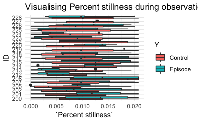

```r
eda_df %>%
  group_by(ID) %>%
  select(ID,
         Event,
         EmotionalEatingEpisodes,
         `Percent stillness`,
         Stress) %>%
  distinct() %>%
  mutate(Y = ifelse(EmotionalEatingEpisodes == 1, "Episode", "Control")) %>%
  filter(!(Stress > 4)) %>%
  ggplot(aes(x=ID,y=`Percent stillness`)) +
  geom_boxplot(aes(fill = Y)) +
  labs(title = "Visualising Percent stillness during observations") +
  theme_minimal() +
  coord_flip()
```

# Temperature

`Temperature` summaries for both episodes and controls:

```r
eda_df %>%
  group_by(ID) %>%
  select(ID,
         Event,
         EmotionalEatingEpisodes,
         Temp,
         Stress) %>%
  distinct() %>%
  mutate(Y = ifelse(EmotionalEatingEpisodes == 1, "Episode", "Control")) %>%
  filter(!(Stress > 4))%>% #filter high stress
  do(tidy(summary(.$Temp))) %>%
  kable(caption = "\"Temperature during observation\" Summary During Episodes and Controls")
```

```
|ID  | minimum|    q1| median|     mean|    q3| maximum|  na|
|:---|-------:|-----:|------:|--------:|-----:|-------:|---:|
|200 |   19.27| 31.93|  33.11| 32.39774| 33.93|  382.18|  54|
|201 |   23.09| 31.63|  33.00| 32.86394| 34.09|  382.18|  35|
|202 |   17.61| 28.79|  30.55| 30.63924| 32.57|  382.18|  80|
|205 |   19.51| 29.63|  31.49| 31.01916| 32.66|  382.18|  59|
|207 |   24.79| 31.73|  32.65| 32.57211| 33.61|  382.21| 135|
|208 |   18.57| 25.19|  28.33| 27.78311| 30.51|  382.18|  86|
|212 |   20.09| 29.87|  31.83| 31.60350| 33.63|  382.18|  69|
|213 |   24.61| 29.99|  31.21| 31.58820| 32.93|  382.18|  75|
|214 |   22.55| 31.67|  32.53| 32.74280| 33.68|  382.21|  81|
|215 |   25.31| 32.07|  33.09| 33.09874| 33.91|  382.18|  67|
|217 |   27.35| 32.79|  33.53| 33.36245| 34.25|   36.79|  63|
|218 |   24.43| 32.05|  33.57| 33.24768| 34.61|   37.15|  29|
|219 |   29.69| 32.21|  33.00| 33.02646| 33.89|   35.91|  62|
|220 |   19.27| 31.45|  32.95| 32.33954| 33.91|   36.79|  76|
|222 |   17.87| 30.63|  32.03| 31.35706| 33.18|   36.05|  56|
|223 |   15.87| 28.37|  29.93| 29.65667| 31.55|   35.53|  41|
|224 |   12.49| 31.41|  32.79| 31.73730| 33.68|   36.66|  38|
|225 |    6.61| 28.67|  30.89| 30.18009| 32.71|   37.21|  72|
|226 |   22.69| 30.01|  31.41| 31.21717| 32.50|   35.45|  53|
|227 |   18.35| 29.57|  31.61| 30.54964| 33.23|   35.63| 108|
|228 |   17.29| 31.59|  33.09| 32.24972| 33.99|   36.57|  69|
```

`Temperature during observation` summaries for episodes:

```r
eda_df %>%
  group_by(ID) %>%
  select(ID,
         Event,
         EmotionalEatingEpisodes,
         Temp,
         Stress) %>%
  distinct() %>%
  mutate(Y = ifelse(EmotionalEatingEpisodes == 1, "Episode", "Control")) %>%
  filter(!(Stress > 4 & Y == "Episode")) %>% #filter high stress
  do(tidy(summary(.$Temp))) %>%
  kable(caption = "\"Temperature during observation\" Summary for Episodes")
```

```
|ID  | minimum|     q1| median|     mean|    q3| maximum|  na|
|:---|-------:|------:|------:|--------:|-----:|-------:|---:|
|200 |   19.27| 31.930|  33.11| 32.39774| 33.93|  382.18|  54|
|201 |   23.09| 31.630|  32.99| 32.85038| 34.07|  382.18|  35|
|202 |   17.61| 28.810|  30.55| 30.64457| 32.55|  382.18|  80|
|205 |   19.51| 29.210|  31.29| 30.70981| 32.55|  382.18|  64|
|207 |   24.79| 31.730|  32.65| 32.57211| 33.61|  382.21| 135|
|208 |   18.57| 25.190|  28.33| 27.78311| 30.51|  382.18|  88|
|212 |   20.09| 29.870|  31.83| 31.60350| 33.63|  382.18|  69|
|213 |   24.61| 29.990|  31.21| 31.58820| 32.93|  382.18|  75|
|214 |   22.55| 31.670|  32.53| 32.74280| 33.68|  382.21|  82|
|215 |   25.31| 32.070|  33.09| 33.09874| 33.91|  382.18|  67|
|217 |   27.35| 32.795|  33.55| 33.36945| 34.27|   36.79|  64|
|218 |   24.43| 32.050|  33.57| 33.24768| 34.61|   37.15|  29|
|219 |   29.69| 32.270|  33.05| 33.04823| 33.84|   35.91|  65|
|220 |   19.27| 31.470|  32.95| 32.35266| 33.89|   36.79|  85|
|222 |   17.87| 30.630|  32.03| 31.35706| 33.18|   36.05|  56|
|223 |   15.87| 28.210|  29.79| 29.53667| 31.45|   35.53|  45|
|224 |   12.49| 31.455|  32.79| 31.80583| 33.68|   36.66|  41|
|225 |    6.61| 28.690|  30.87| 30.20085| 32.72|   37.21|  74|
|226 |   22.69| 30.010|  31.41| 31.21717| 32.50|   35.45|  53|
|227 |   18.35| 29.570|  31.61| 30.54964| 33.23|   35.63| 108|
|228 |   17.29| 31.350|  33.03| 32.08970| 33.97|   36.57|  74|
```

`Temperature during observation` summaries for controls:

```r
eda_df %>%
  group_by(ID) %>%
  select(ID,
         Event,
         EmotionalEatingEpisodes,
         Temp,
         Stress) %>%
  distinct() %>%
  mutate(Y = ifelse(EmotionalEatingEpisodes == 1, "Episode", "Control")) %>%
  filter(!(Stress > 4 & Y == "Control"))%>% #filter high stress
  do(tidy(summary(.$Temp))) %>%
  kable(caption = "\"Temperature during observation\" Summary for Controls")
```

```
|ID  | minimum|    q1| median|     mean|    q3| maximum|  na|
|:---|-------:|-----:|------:|--------:|-----:|-------:|---:|
|200 |   19.27| 31.93|  33.11| 32.39774| 33.93|  382.18|  54|
|201 |   23.09| 31.63|  33.00| 32.86394| 34.09|  382.18|  35|
|202 |   17.61| 28.79|  30.55| 30.63924| 32.57|  382.18|  80|
|205 |   19.51| 29.67|  31.45| 31.04239| 32.61|  382.18|  59|
|207 |   24.79| 31.75|  32.65| 32.57481| 33.61|  382.21| 136|
|208 |   18.57| 25.19|  28.33| 27.78311| 30.51|  382.18|  86|
|212 |   20.09| 29.87|  31.83| 31.60350| 33.63|  382.18|  69|
|213 |   24.61| 29.99|  31.21| 31.58820| 32.93|  382.18|  75|
|214 |   22.55| 31.67|  32.53| 32.80440| 33.71|  382.21|  81|
|215 |   25.31| 32.07|  33.09| 33.09874| 33.91|  382.18|  67|
|217 |   27.35| 32.77|  33.50| 33.35372| 34.23|   36.79|  63|
|218 |   24.43| 32.05|  33.57| 33.24768| 34.61|   37.15|  29|
|219 |   29.69| 32.21|  33.00| 33.03598| 33.91|   35.91|  62|
|220 |   19.27| 31.45|  32.95| 32.33954| 33.91|   36.79|  76|
|222 |   17.87| 30.63|  32.03| 31.35706| 33.18|   36.05|  56|
|223 |   15.87| 28.03|  29.79| 29.27838| 31.43|   35.53|  42|
|224 |   12.49| 31.41|  32.79| 31.73730| 33.68|   36.66|  38|
|225 |    6.61| 28.69|  30.89| 30.19340| 32.71|   37.21|  72|
|226 |   22.69| 30.01|  31.41| 31.21717| 32.50|   35.45|  53|
|227 |   18.35| 29.51|  31.55| 30.53184| 33.21|   35.63| 108|
|228 |   17.29| 31.59|  33.09| 32.24972| 33.99|   36.57|  69|
```

Visualised:

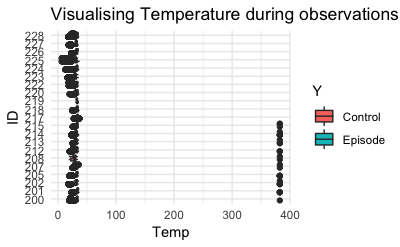

```r
eda_df %>%
  group_by(ID) %>%
  select(ID,
         Event,
         EmotionalEatingEpisodes,
         Temp,
         Stress) %>%
  distinct() %>%
  mutate(Y = ifelse(EmotionalEatingEpisodes == 1, "Episode", "Control")) %>%
  filter(!(Stress > 4)) %>%
  ggplot(aes(x=ID,y=Temp)) +
  geom_boxplot(aes(fill = Y)) +
  labs(title = "Visualising Temperature during observations") +
  theme_minimal() +
  coord_flip()
```

Lots of outliers =D

# Motion

## Aggregate motion during observations

This is `sqrt(X^2+Y^2+Z^2)`

`Motion` summaries for both episodes and controls:

```r
eda_df %>%
  group_by(ID) %>%
  select(ID,
         Event,
         EmotionalEatingEpisodes,
         motion,
         Stress) %>%
  distinct() %>%
  mutate(Y = ifelse(EmotionalEatingEpisodes == 1, "Episode", "Control")) %>%
  filter(!(Stress > 4))%>% #filter high stress
  do(tidy(summary(.$motion))) %>%
  kable(caption = "\"3 dimensional motion during observation\" Summary During Episodes and Controls")
```

```
|=============================================|100% ~0 s remaining

|ID  |   minimum|        q1|   median|     mean|       q3|  maximum|  na|
|:---|---------:|---------:|--------:|--------:|--------:|--------:|---:|
|200 | 0.0156250| 0.9181599| 1.026980| 1.063217| 1.168432| 3.455104|  53|
|201 | 0.0349386| 0.9075960| 1.032315| 1.083544| 1.220151| 3.455104|  34|
|202 | 0.0441942| 0.9118898| 1.027217| 1.059105| 1.171771| 3.464102|  79|
|205 | 0.0220971| 0.8896651| 1.010444| 1.050100| 1.172292| 3.455104|  53|
|207 | 0.0382733| 0.9047671| 1.007540| 1.032565| 1.133863| 3.455104| 132|
|208 | 0.0732877| 0.9371093| 1.023527| 1.064427| 1.145857| 3.464102|  85|
|212 | 0.0382733| 0.9170957| 1.030895| 1.074071| 1.181213| 3.464102|  68|
|213 | 0.0382733| 0.9200193| 1.040794| 1.102745| 1.237240| 3.464102|  74|
|214 | 0.0156250| 0.9326698| 1.032433| 1.073978| 1.176968| 3.446083|  76|
|215 | 0.0716027| 0.9350228| 1.029117| 1.057850| 1.156778| 3.446083|  67|
|217 | 0.0494106| 0.9168294| 1.032315| 1.078833| 1.207682| 3.455104|  58|
|218 | 0.0662913| 0.9176279| 1.028287| 1.068859| 1.178626| 3.455104|  29|
|219 | 0.0349386| 0.9073269| 1.003047| 1.031004| 1.123914| 3.446083|  60|
|220 | 0.0563367| 0.9259708| 1.035856| 1.066881| 1.178005| 3.455104|  77|
|222 | 0.0270633| 0.9242554| 1.038093| 1.086179| 1.213329| 3.455104|  53|
|223 | 0.0382733| 0.9017940| 1.010444| 1.049081| 1.158886| 3.464102|  38|
|224 | 0.0156250| 0.9271565| 1.044540| 1.096653| 1.217247| 3.464102|  38|
|225 | 0.0220971| 0.9198866| 1.030895| 1.070517| 1.178626| 3.464102|  69|
|226 | 0.0349386| 0.9196212| 1.014302| 1.048540| 1.140197| 3.464102|  48|
|227 | 0.0270633| 0.9318842| 1.027217| 1.071625| 1.176138| 3.455104| 107|
|228 | 0.0494106| 0.9126926| 1.020900| 1.069810| 1.167387| 3.455104|  66|
```

`Motion during observation` summaries for episodes:

```r
eda_df %>%
  group_by(ID) %>%
  select(ID,
         Event,
         EmotionalEatingEpisodes,
         motion,
         Stress) %>%
  distinct() %>%
  mutate(Y = ifelse(EmotionalEatingEpisodes == 1, "Episode", "Control")) %>%
  filter(!(Stress > 4 & Y == "Episode")) %>% #filter high stress
  do(tidy(summary(.$motion))) %>%
  kable(caption = "\"3 dimensional motion during observation\" Summary for Episodes")
```

```
|=============================================|100% ~0 s remaining

|ID  |   minimum|        q1|   median|     mean|       q3|  maximum|  na|
|:---|---------:|---------:|--------:|--------:|--------:|--------:|---:|
|200 | 0.0156250| 0.9181599| 1.026980| 1.063217| 1.168432| 3.455104|  53|
|201 | 0.0349386| 0.9079994| 1.031842| 1.082987| 1.218850| 3.455104|  34|
|202 | 0.0441942| 0.9117559| 1.027574| 1.059608| 1.172812| 3.464102|  79|
|205 | 0.0220971| 0.8889787| 1.010323| 1.049169| 1.171875| 3.455104|  58|
|207 | 0.0382733| 0.9047671| 1.007540| 1.032565| 1.133863| 3.455104| 132|
|208 | 0.0732877| 0.9371093| 1.023527| 1.064427| 1.145857| 3.464102|  87|
|212 | 0.0382733| 0.9170957| 1.030895| 1.074071| 1.181213| 3.464102|  68|
|213 | 0.0382733| 0.9200193| 1.040794| 1.102745| 1.237240| 3.464102|  74|
|214 | 0.0156250| 0.9326698| 1.032433| 1.073978| 1.176968| 3.446083|  77|
|215 | 0.0716027| 0.9350228| 1.029117| 1.057850| 1.156778| 3.446083|  67|
|217 | 0.0494106| 0.9169625| 1.031842| 1.078124| 1.206064| 3.455104|  59|
|218 | 0.0662913| 0.9176279| 1.028287| 1.068859| 1.178626| 3.455104|  29|
|219 | 0.0349386| 0.9050369| 1.003899| 1.032658| 1.129440| 3.446083|  63|
|220 | 0.0518223| 0.9259708| 1.035974| 1.066813| 1.177798| 3.455104|  86|
|222 | 0.0270633| 0.9242554| 1.038093| 1.086179| 1.213329| 3.455104|  53|
|223 | 0.0382733| 0.9038222| 1.009356| 1.046911| 1.153925| 3.464102|  42|
|224 | 0.0156250| 0.9267614| 1.044657| 1.097246| 1.218149| 3.464102|  41|
|225 | 0.0220971| 0.9200193| 1.030895| 1.070623| 1.178108| 3.464102|  70|
|226 | 0.0349386| 0.9196212| 1.014302| 1.048540| 1.140197| 3.464102|  48|
|227 | 0.0270633| 0.9318842| 1.027217| 1.071625| 1.176138| 3.455104| 107|
|228 | 0.0494106| 0.9129601| 1.020661| 1.069273| 1.166760| 3.455104|  71|
```

`Motion during observation` summaries for controls:

```r
eda_df %>%
  group_by(ID) %>%
  select(ID,
         Event,
         EmotionalEatingEpisodes,
         motion,
         Stress) %>%
  distinct() %>%
  mutate(Y = ifelse(EmotionalEatingEpisodes == 1, "Episode", "Control")) %>%
  filter(!(Stress > 4 & Y == "Control"))%>% #filter high stress
  do(tidy(summary(.$motion))) %>%
  kable(caption = "\"3 dimensional motion during observation\" Summary for Controls")
```

```
|=============================================|100% ~0 s remaining

|ID  |   minimum|        q1|   median|     mean|       q3|  maximum|  na|
|:---|---------:|---------:|--------:|--------:|--------:|--------:|---:|
|200 | 0.0156250| 0.9181599| 1.026980| 1.063217| 1.168432| 3.455104|  53|
|201 | 0.0349386| 0.9075960| 1.032315| 1.083544| 1.220151| 3.455104|  34|
|202 | 0.0441942| 0.9118898| 1.027217| 1.059105| 1.171771| 3.464102|  79|
|205 | 0.0220971| 0.8895278| 1.011289| 1.050469| 1.173644| 3.455104|  53|
|207 | 0.0382733| 0.9043623| 1.007903| 1.032738| 1.134508| 3.455104| 133|
|208 | 0.0732877| 0.9371093| 1.023527| 1.064427| 1.145857| 3.464102|  85|
|212 | 0.0382733| 0.9170957| 1.030895| 1.074071| 1.181213| 3.464102|  68|
|213 | 0.0382733| 0.9200193| 1.040794| 1.102745| 1.237240| 3.464102|  74|
|214 | 0.0156250| 0.9326698| 1.032315| 1.073922| 1.176864| 3.446083|  76|
|215 | 0.0716027| 0.9350228| 1.029117| 1.057850| 1.156778| 3.446083|  67|
|217 | 0.0494106| 0.9161635| 1.032196| 1.078423| 1.206873| 3.455104|  58|
|218 | 0.0662913| 0.9176279| 1.028287| 1.068859| 1.178626| 3.455104|  29|
|219 | 0.0349386| 0.9075960| 1.002925| 1.030910| 1.123480| 3.446083|  60|
|220 | 0.0563367| 0.9259708| 1.035856| 1.066881| 1.178005| 3.455104|  77|
|222 | 0.0270633| 0.9242554| 1.038093| 1.086179| 1.213329| 3.455104|  53|
|223 | 0.0382733| 0.9019294| 1.010081| 1.048330| 1.157305| 3.464102|  39|
|224 | 0.0156250| 0.9271565| 1.044540| 1.096653| 1.217247| 3.464102|  38|
|225 | 0.0220971| 0.9196876| 1.030421| 1.070052| 1.177383| 3.464102|  69|
|226 | 0.0349386| 0.9196212| 1.014302| 1.048540| 1.140197| 3.464102|  48|
|227 | 0.0270633| 0.9324080| 1.027217| 1.071538| 1.174788| 3.455104| 107|
|228 | 0.0494106| 0.9126926| 1.020900| 1.069810| 1.167387| 3.455104|  66|
```

Visualised:

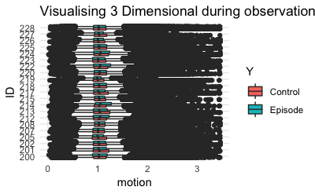

```r
eda_df %>%
  group_by(ID) %>%
  select(ID,
         Event,
         EmotionalEatingEpisodes,
         motion,
         Stress) %>%
  distinct() %>%
  mutate(Y = ifelse(EmotionalEatingEpisodes == 1, "Episode", "Control")) %>%
  filter(!(Stress > 4)) %>%
  ggplot(aes(x=ID,y=motion)) +
  geom_boxplot(aes(fill = Y)) +
  labs(title = "Visualising 3 Dimensional during observations") +
  theme_minimal() +
  coord_flip()
```

Even more outliers! =D

# EDA Peaks

## Number of Peaks by Participant

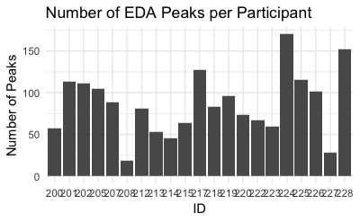

```r
eda_df %>%
  select(ID,
         Event,
         EmotionalEatingEpisodes,
         peaks,
         Stress) %>%
  distinct() %>%
  mutate(Y = ifelse(EmotionalEatingEpisodes == 1, "Episode", "Control"),
         peaks = as.numeric(peaks)) %>%
  filter(!(Stress > 4 & Y == "Control")) %>%
  group_by(ID) %>%
  summarise(peaks2 = sum(peaks, na.rm = TRUE)) %>%
  ggplot(aes(x=ID,y=peaks2)) +
    geom_col()+
    theme_minimal() +
    labs(title = "Number of EDA Peaks per Participant", y = "Number of Peaks")
```

## Number of Peaks by Condition

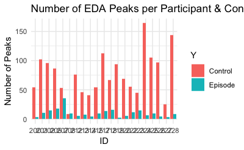

```r
eda_df %>%
  select(ID,
         Event,
         EmotionalEatingEpisodes,
         peaks,
         Stress) %>%
  distinct() %>%
  mutate(Y = ifelse(EmotionalEatingEpisodes == 1, "Episode", "Control"),
         peaks = as.numeric(peaks)) %>%
  filter(!(Stress > 4 & Y == "Control")) %>%
  group_by(ID, Y) %>%
  summarise(peaks2 = sum(peaks, na.rm = TRUE)) %>%
  ggplot(aes(x=ID,y=peaks2)) +
    geom_col(aes(fill = Y), position = "dodge") +
    theme_minimal() +
    labs(title = "Number of EDA Peaks per Participant & Condition", y = "Number of Peaks")
```

# EDA Values

## Amplitude

`Peak Amplitude` summaries for both episodes and controls:

```r
eda_df %>%
  group_by(ID) %>%
  select(ID,
         Event,
         EmotionalEatingEpisodes,
         amp,
         Stress) %>%
  distinct() %>%
  mutate(Y = ifelse(EmotionalEatingEpisodes == 1, "Episode", "Control")) %>%
  filter(!(Stress > 4 & Y == "Control"))%>% #filter high stress
  do(tidy(summary(.$amp))) %>%
  kable(caption = "\"EDA Peak Amplitude\" Summary During Episodes and Controls")
```

```
|ID  | minimum|        q1|    median|      mean|        q3|  maximum|  na|
|:---|-------:|---------:|---------:|---------:|---------:|--------:|---:|
|200 |       0| 0.0345785| 0.0870830| 0.1951758| 0.2318825| 5.211616|  52|
|201 |       0| 0.0435020| 0.1100750| 0.1989671| 0.2591340| 3.031622|  34|
|202 |       0| 0.0320185| 0.0627630| 0.1692375| 0.1729120| 4.471388|  78|
|205 |       0| 0.0307310| 0.0640040| 0.1963009| 0.1690040| 6.587971|  51|
|207 |       0| 0.0281790| 0.0550740| 0.1268513| 0.1562660| 1.711874| 133|
|208 |       0| 0.0000000| 0.0307350| 0.0612394| 0.0633915| 1.276264|  84|
|212 |       0| 0.0461170| 0.1370775| 0.3123153| 0.3881327| 6.701617|  68|
|213 |       0| 0.0512160| 0.1421340| 0.4159235| 0.4140270| 6.702685|  73|
|214 |       0| 0.0508183| 0.1129170| 0.2195640| 0.2327193| 5.875226|  75|
|215 |       0| 0.0307410| 0.0678860| 0.1622205| 0.1665130| 5.729257|  67|
|217 |       0| 0.0499630| 0.1204415| 0.3634630| 0.3037538| 6.542019|  57|
|218 |       0| 0.0537280| 0.1202860| 0.1751021| 0.2354455| 4.004387|  29|
|219 |       0| 0.0422260| 0.0946760| 0.1822812| 0.2085300| 6.081795|  58|
|220 |       0| 0.0499420| 0.1472640| 0.2681747| 0.3907885| 2.592065|  76|
|222 |       0| 0.0296328| 0.0691880| 0.1375646| 0.1780380| 2.228320|  53|
|223 |       0| 0.0281820| 0.0512530| 0.2021686| 0.1434830| 5.025111|  37|
|224 |       0| 0.0422732| 0.1084805| 0.2057423| 0.2613760| 5.821736|  37|
|225 |       0| 0.0384080| 0.1049550| 0.2145997| 0.2831180| 5.236912|  68|
|226 |       0| 0.0422760| 0.0925060| 0.2564740| 0.2421280| 6.615104|  48|
|227 |       0| 0.0281670| 0.0486440| 0.0945442| 0.1159010| 1.842902| 107|
|228 |       0| 0.0332770| 0.0767640| 0.3964351| 0.3221720| 6.842103|  65|
```

Peak amplitude summaries for episodes:

```r
eda_df %>%
  group_by(ID) %>%
  select(ID,
         Event,
         EmotionalEatingEpisodes,
         amp,
         Stress) %>%
  distinct() %>%
  mutate(Y = ifelse(EmotionalEatingEpisodes == 1, "Episode", "Control")) %>%
  filter(!(Stress > 4 & Y == "Control") & Y == "Episode")%>% #filter high stress
  do(tidy(summary(.$amp))) %>%
  kable(caption = "\"Peak Amplitude\" Summary During Episodes")
```

[output not shown]

`Peak Amplitude` summaries for controls:

```r
eda_df %>%
  group_by(ID) %>%
  select(ID,
         Event,
         EmotionalEatingEpisodes,
         amp,
         Stress) %>%
  distinct() %>%
  mutate(Y = ifelse(EmotionalEatingEpisodes == 1, "Episode", "Control")) %>%
  filter(!(Stress > 4 & Y == "Control") & Y != "Episode")%>% #filter high stress
  do(tidy(summary(.$amp))) %>%
  kable(caption = "\"Peak Amplitude\" Summary During Episodes")
```

[output not shown]

Visualised:

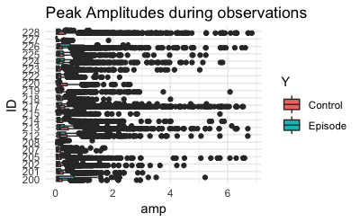

```r
eda_df %>%
  group_by(ID) %>%
  select(ID,
         Event,
         EmotionalEatingEpisodes,
         amp,
         Stress) %>%
  distinct() %>%
  mutate(Y = ifelse(EmotionalEatingEpisodes == 1, "Episode", "Control")) %>%
  filter(!(Stress > 4 & Y == "Control")) %>%
  ggplot(aes(x=ID,y=amp)) +
  geom_boxplot(aes(fill = Y)) +
  labs(title = "Peak Amplitudes during observations") +
  theme_minimal() +
  coord_flip()
```

## Max Derivative

This is defined as max derivative within 1 second of apex of SCR

`Max Deriv` summaries for both episodes and controls:

```r
eda_df %>%
  group_by(ID) %>%
  select(ID,
         Event,
         EmotionalEatingEpisodes,
         max_deriv,
         Stress) %>%
  distinct() %>%
  mutate(Y = ifelse(EmotionalEatingEpisodes == 1, "Episode", "Control")) %>%
  filter(!(Stress > 4 & Y == "Control"))%>% #filter high stress
  do(tidy(summary(.$max_deriv))) %>%
  kable(caption = "\"Max Derivative\" Summary During Episodes and Controls")
```

```
|ID  | minimum|        q1|    median|      mean|        q3|  maximum|  na|
|:---|-------:|---------:|---------:|---------:|---------:|--------:|---:|
|200 |       0| 0.0673841| 0.1793191| 0.3478069| 0.3935603| 3.354666|  52|
|201 |       0| 0.0764819| 0.1717979| 0.3158187| 0.3747894| 3.502699|  34|
|202 |       0| 0.0532058| 0.1114654| 0.2703686| 0.2617166| 3.253463|  78|
|205 |       0| 0.0477406| 0.1034057| 0.2619436| 0.2578079| 3.328650|  51|
|207 |       0| 0.0467272| 0.1066564| 0.2062020| 0.2463942| 3.108277| 133|
|208 |       0| 0.0023648| 0.0422408| 0.0923294| 0.0942754| 2.203169|  84|
|212 |       0| 0.0810833| 0.2279198| 0.4600030| 0.5732314| 3.452593|  68|
|213 |       0| 0.1029725| 0.2552076| 0.6172125| 0.7283586| 3.732071|  73|
|214 |       0| 0.0767753| 0.1612013| 0.2920414| 0.3132686| 3.796109|  75|
|215 |       0| 0.0516036| 0.1222729| 0.2800002| 0.2708980| 3.268574|  67|
|217 |       0| 0.1091738| 0.2325663| 0.5683579| 0.6487461| 3.664070|  57|
|218 |       0| 0.0919202| 0.1740073| 0.2370731| 0.3047097| 3.252927|  29|
|219 |       0| 0.0797444| 0.1863755| 0.3352387| 0.3846351| 3.434331|  58|
|220 |       0| 0.1018170| 0.2642999| 0.4574165| 0.7174868| 2.730997|  76|
|222 |       0| 0.0496120| 0.1296008| 0.2350471| 0.2889590| 2.552670|  53|
|223 |       0| 0.0392634| 0.1054448| 0.3382910| 0.2691422| 3.378505|  37|
|224 |       0| 0.0801328| 0.1878703| 0.3305858| 0.4012165| 3.595709|  37|
|225 |       0| 0.0684913| 0.1832699| 0.3315618| 0.4468798| 3.442575|  68|
|226 |       0| 0.0836584| 0.1944865| 0.4893554| 0.5505447| 3.726016|  48|
|227 |       0| 0.0304023| 0.0770971| 0.1457683| 0.1732465| 2.380648| 107|
|228 |       0| 0.0549063| 0.1520161| 0.5511675| 0.8554650| 3.683922|  65|
```

`Max Derivative` summaries for episodes:

```r
eda_df %>%
  group_by(ID) %>%
  select(ID,
         Event,
         EmotionalEatingEpisodes,
         max_deriv,
         Stress) %>%
  distinct() %>%
  mutate(Y = ifelse(EmotionalEatingEpisodes == 1, "Episode", "Control")) %>%
  filter(!(Stress > 4 & Y == "Control") & Y == "Episode")%>% #filter high stress
  do(tidy(summary(.$max_deriv))) %>%
  kable(caption = "\"Max Derivative\" Summary During Episodes")
```

```
|ID  | minimum|        q1|    median|      mean|        q3|   maximum| na|
|:---|-------:|---------:|---------:|---------:|---------:|---------:|--:|
|200 |       0| 0.0616095| 0.2318539| 0.7795550| 1.2873998| 3.3546657|  8|
|201 |       0| 0.0483664| 0.1002739| 0.1571926| 0.2081406| 0.7103130|  3|
|202 |       0| 0.0463652| 0.0855040| 0.1564976| 0.1740428| 2.3546328| 15|
|205 |       0| 0.0464295| 0.0718692| 0.1205722| 0.1427623| 1.3961714|  2|
|207 |       0| 0.0351928| 0.0806949| 0.1929652| 0.1936970| 3.1082773| 33|
|208 |       0| 0.0226209| 0.0478892| 0.1117364| 0.1148970| 2.2031689| 35|
|212 |       0| 0.1197163| 0.2799376| 0.5061983| 0.6470318| 3.2173772|  6|
|213 |       0| 0.1119894| 0.2685864| 0.5854149| 0.6625741| 3.4531548| 19|
|214 |       0| 0.0535932| 0.1112873| 0.1258057| 0.1738396| 0.5033232|  3|
|215 |       0| 0.0269079| 0.0491193| 0.1854417| 0.1308782| 2.1589561|  9|
|217 |       0| 0.0879337| 0.1798484| 0.4162474| 0.4297686| 3.5891879|  5|
|218 |       0| 0.0500837| 0.0931746| 0.1323917| 0.1659282| 1.1986356|  1|
|219 |       0| 0.0324766| 0.0720298| 0.1381857| 0.1488047| 0.6328475| NA|
|220 |       0| 0.0440718| 0.0619045| 0.0799228| 0.0907956| 0.3101451| NA|
|222 |       0| 0.0609351| 0.1344019| 0.2066958| 0.2585077| 2.1616795|  3|
|223 |       0| 0.0420092| 0.1174164| 0.2022487| 0.2411545| 2.0254842|  9|
|224 |       0| 0.0894014| 0.2107108| 0.3541622| 0.5011374| 2.1898690|  1|
|225 |       0| 0.0703129| 0.1687944| 0.2463991| 0.3600111| 1.2138675|  6|
|226 |       0| 0.1185202| 0.2931873| 0.6843201| 1.1577577| 3.7260159|  3|
|227 |       0| 0.0351038| 0.0506642| 0.0702488| 0.0824347| 0.2736954|  1|
|228 |       0| 0.0581166| 0.1376362| 0.2281010| 0.2856795| 2.2845539|  9|
```

`Max Derivative` summaries for controls:

```r
eda_df %>%
  group_by(ID) %>%
  select(ID,
         Event,
         EmotionalEatingEpisodes,
         max_deriv,
         Stress) %>%
  distinct() %>%
  mutate(Y = ifelse(EmotionalEatingEpisodes == 1, "Episode", "Control")) %>%
  filter(!(Stress > 4 & Y == "Control") & Y != "Episode")%>% #filter high stress
  do(tidy(summary(.$max_deriv))) %>%
  kable(caption = "\"Max Derivative\" Summary During Episodes")
```

```
|ID  | minimum|        q1|    median|      mean|        q3|   maximum|  na|
|:---|-------:|---------:|---------:|---------:|---------:|---------:|---:|
|200 |       0| 0.0684498| 0.1773294| 0.3260955| 0.3868334| 2.7349808|  44|
|201 |       0| 0.0781799| 0.1753257| 0.3235026| 0.3815400| 3.5026991|  31|
|202 |       0| 0.0545194| 0.1144524| 0.2824177| 0.2720958| 3.2534630|  63|
|205 |       0| 0.0479757| 0.1124615| 0.2849880| 0.2799487| 3.3286497|  49|
|207 |       0| 0.0552980| 0.1203367| 0.2131103| 0.2783109| 2.4255146| 100|
|208 |       0| 0.0000000| 0.0337749| 0.0584354| 0.0699170| 0.2883108|  49|
|212 |       0| 0.0776569| 0.2261606| 0.4551966| 0.5679898| 3.4525933|  62|
|213 |       0| 0.1023013| 0.2542709| 0.6209462| 0.7396748| 3.7320709|  54|
|214 |       0| 0.0802945| 0.1685440| 0.3059623| 0.3291927| 3.7961090|  72|
|215 |       0| 0.0568129| 0.1276917| 0.2860983| 0.2765788| 3.2685737|  58|
|217 |       0| 0.1117275| 0.2410117| 0.5876864| 0.6810070| 3.6640697|  52|
|218 |       0| 0.0995241| 0.1860178| 0.2479164| 0.3168473| 3.2529271|  28|
|219 |       0| 0.0803809| 0.1871954| 0.3366406| 0.3856470| 3.4343309|  58|
|220 |       0| 0.1079259| 0.2686433| 0.4641442| 0.7255425| 2.7309970|  76|
|222 |       0| 0.0473987| 0.1267722| 0.2427105| 0.2990860| 2.5526698|  50|
|223 |       0| 0.0389657| 0.0991741| 0.3819311| 0.2895516| 3.3785047|  28|
|224 |       0| 0.0798048| 0.1874003| 0.3294694| 0.3981958| 3.5957094|  36|
|225 |       0| 0.0682626| 0.1846256| 0.3378305| 0.4583754| 3.4425746|  62|
|226 |       0| 0.0829980| 0.1904713| 0.4811617| 0.5333284| 3.6997912|  45|
|227 |       0| 0.0298073| 0.0802328| 0.1494315| 0.1758956| 2.3806479| 106|
|228 |       0| 0.0548329| 0.1553863| 0.5693537| 0.8827498| 3.6839218|  56|
```

Visualised:

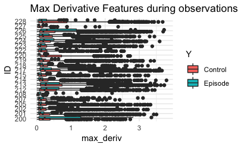

```r
eda_df %>%
  group_by(ID) %>%
  select(ID,
         Event,
         EmotionalEatingEpisodes,
         max_deriv,
         Stress) %>%
  distinct() %>%
  mutate(Y = ifelse(EmotionalEatingEpisodes == 1, "Episode", "Control")) %>%
  filter(!(Stress > 4 & Y == "Control")) %>%
  ggplot(aes(x=ID,y=max_deriv)) +
  geom_boxplot(aes(fill = Y)) +
  labs(title = "Max Derivative Features during observations") +
  theme_minimal() +
  coord_flip()
```